# Summary of Waterloo Region Vote Intention, Spring 2021

# 3 Federal Vote Intention, Spring 2021

Figure 3.1 shows the weighted federal vote intention of all voters, *including undecided voters*, in Waterloo Region, spring 2021.

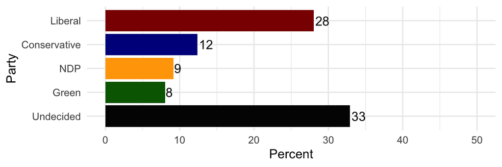

Figure 3.1: Distribution of Federal Vote Intention, Waterloo Region 2021

Figure 3.2 shows the weighted federal vote intention in Waterloo Region, spring 2021, *excluding* undecided voters.

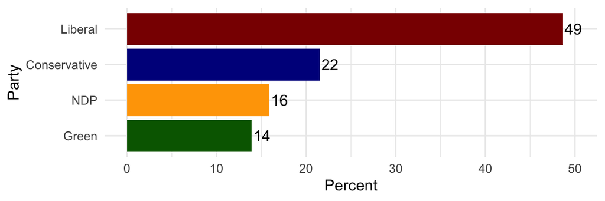

Figure 3.2: Distribution of Federal Vote Intention, Decided Voters Only, Waterloo Region 2021

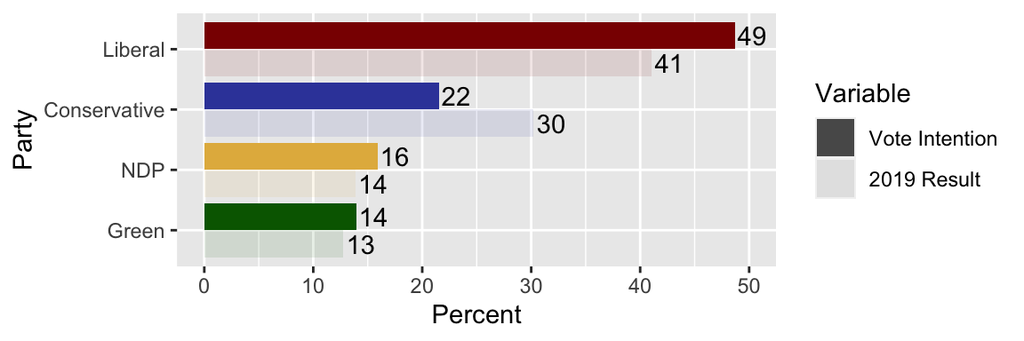

Figure 3.3: Federal Vote Intention By 2019 Result

To add a bit of context we can compare these with the last election’s results. Figure 3.3 shows the current results of *decided* voters only, compared to the results of the 2019 federal election. Note that the Liberals were eight points ahead than their 2019 results, while the Conservatives were behind their past results.

Lastly, we can also compare the spring survey of voters with the historic average levels of support received by the parties in Waterloo Region. Figure 3.4 shows this, including only *decided voters*.

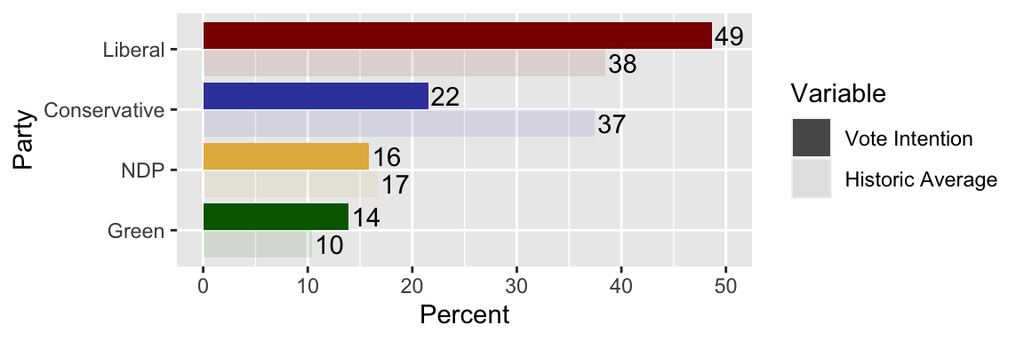

Figure 3.4: Federal Vote Intention Compared To Historic Averages

## 3.1 Assessment Of Federal Handling Of The Pandemic

Table 3.1 shows that 61% of the respondents approved of how Trudeau had handled the pandemic.

Table 3.1: Support For Trudeau’s Handling of The Pandemic

| Approval | Pct |
| --- | --- |
| Approve | 61 |
| Disapprove | 29 |
| Neither | 10 |

If we break it out by vote intention, obviously we get different results. Figure 3.5 shows the assessment of Prime Minister Justin Trudeau's handling of the pandemic by reported vote in the 2021 federal election.

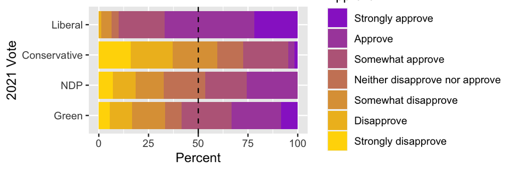

Figure 3.5: Approval of Trudeau handling by 2021 Vote Intention

More specifically, table 3.2 shows that 73% of people who voted Liberal and 16% of people who voted Conservative approved of the job that Justin Trudeau has done handling the pandemic.

Table 3.2: Approval of Trudeau’s Handling Of The Pandemic By Past Vote

|  | Approve | Neither | Disapprove |
| --- | --- | --- | --- |
| Liberal | 73 | 7 | 20 |
| Conservative | 16 | 13 | 71 |
| NDP | 54 | 17 | 28 |
| Green | 40 | 19 | 41 |
| Other | 9 | 29 | 61 |
| Did Not Vote | 59 | 29 | 12 |
| DK | 61 | 24 | 15 |